# Module-15

Julie Jung

November 7, 2017

Install these packages in R: {curl}, {ggplot2}, {gridExtra}, {dplyr}, {car}

constructing a dataset ourselves of some correlated random normal continuous variables.

we define a matrix of correlations among our variables (you can play with the values in this matrix, but it must be symmetric):

```r
R = matrix(cbind(1, 0.8, -0.5, 0, 0.8, 1, -0.3, 0.3, -0.5, -0.3, 1, 0.6, 0,
    0.3, 0.6, 1), nrow = 4)
```

Second, let’s generate a dataset of random normal variables where each has a defined mean and standard deviation and then bundle these into a matrix (“M”) and a dataframe (“orig”):

```r
n <- 1000
k <- 4
M <- NULL
V <- NULL
mu <- c(15, 40, 5, 23)  # vector of variable means
s <- c(5, 20, 4, 15)  # vector of variable SDs
for (i in 1:k) {
    V <- rnorm(n, mu[i], s[i])
    M <- cbind(M, V)
}
M <- matrix(M, nrow = n, ncol = k)
orig <- as.data.frame(M)
names(orig) = c("Y", "X1", "X2", "X3")
head(orig)
```

```
##           Y        X1         X2       X3
## 1 19.461125 64.580746 10.5799118 28.26367
## 2 14.014247  5.341014  0.7222322 21.41226
## 3 22.349526 47.788925  7.1439594 25.10727
## 4  9.771728 72.590249  5.4797253 31.71899
## 5 20.746587 26.251835  3.6897164 27.00585
## 6 15.608773 16.976750 -1.7142611 11.95769
```

```r
cor(orig)  # variables are uncorrelated
```

```
##              Y          X1          X2          X3
## Y   1.00000000 -0.01158953 -0.04372413 -0.04097786
## X1 -0.01158953  1.00000000  0.04377321  0.02771281
## X2 -0.04372413  0.04377321  1.00000000 -0.06386160
## X3 -0.04097786  0.02771281 -0.06386160  1.00000000
```

ideal condition is that none is correlated with each other

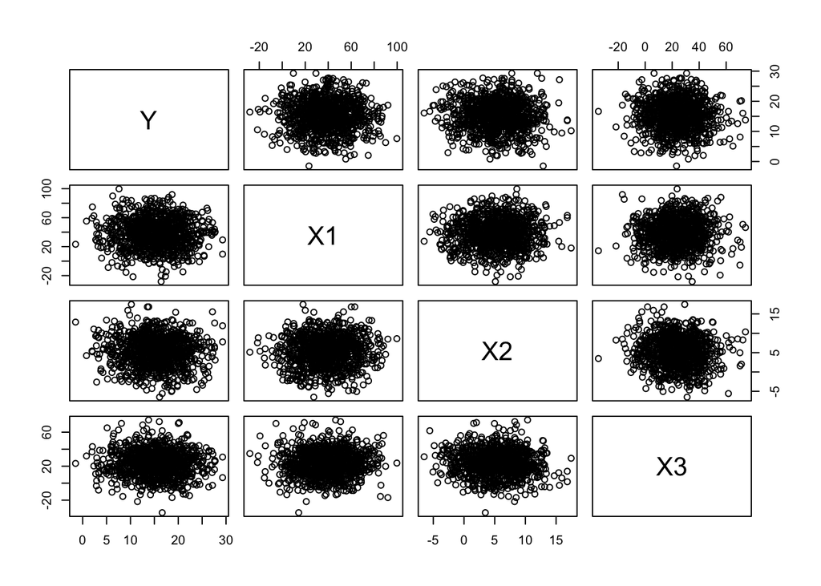

```r
plot(orig)  # does quick bivariate plots for each pair of variables; using `pairs(orig)` would do the same
```

no correlation - no covariance - is ideal.

Now, let’s normalize and standardize our variables by subtracting the relevant means and dividing by the standard deviation. This converts them to Z scores from a standard normal distribution.

```r
ms <- apply(orig, 2, FUN = "mean")  # returns a vector of means, where we are taking this across dimension 2 of the array 'orig'
ms
```

```
##         Y        X1        X2        X3
## 15.284535 38.492125  5.218982 23.719583
```

```r
sds <- apply(orig, 2, FUN = "sd")
sds
```

```
##         Y        X1        X2        X3
##  5.060324 20.068605  3.897650 15.072046
```

```r
## sweep the change across orig dataset
# 2 - sweep across columns, not rows
# subtract stdarized mean from regular mean

normalized <- sweep(orig, 2, STATS = ms, FUN = "-")  # 2nd dimension is columns, removing array of means, function = subtract
normalized <- sweep(normalized, 2, STATS = sds, FUN = "/")  # 2nd dimension is columns, scaling by array of sds, function = divide
head(normalized)  # now a dataframe of Z scores
```

```
##             Y         X1          X2          X3
## 1  0.82536012  1.2999718  1.37542600  0.30149096
## 2 -0.25102901 -1.6518892 -1.15370805 -0.15308615
## 3  1.39615373  0.4632509  0.49388140  0.09207045
## 4 -1.08941782  1.6990780  0.06689743  0.53074451
## 5  1.07938771 -0.6099223 -0.39235592  0.21803704
## 6  0.06407439 -1.0720912 -1.77882656 -0.78037803
```

```r
M <- as.matrix(normalized)  # redefine M as our matrix of normalized variables
# bc it's more useful for some of the functions we'll use
```

With apply() we apply a function to the specified margin of an array or matrix, and with sweep() we then perform whatever function is specified on all of the elements in an array specified by the given margin.

in order to alter our dataset and standardize it.

```r
U = chol(R)
newM = M %*% U #M is our normalized data matrix #U is our decomposed data matrix
new = as.data.frame(newM)
names(new) = c("Y", "X1", "X2", "X3") #rename columns
cor(new)  # note that is correlation matrix is what we are aiming for!
```

```
##              Y         X1         X2          X3
## Y   1.00000000  0.7974951 -0.5257251 -0.05777159
## X1  0.79749514  1.0000000 -0.2995730  0.28226504
## X2 -0.52572505 -0.2995730  1.0000000  0.60710780
## X3 -0.05777159  0.2822650  0.6071078  1.00000000
```

```r
#replicates the defined correlation relationships that we wanted in the beginning

# this is how you create a fake dataset that is consistent with the stuff/qualities you want a fake datset to look like
```

<sup>^</sup> this is the way we impose the correlation structure to our non-correlated, created dataset (M).

yield a transformed dataset with the specified correlation among variables

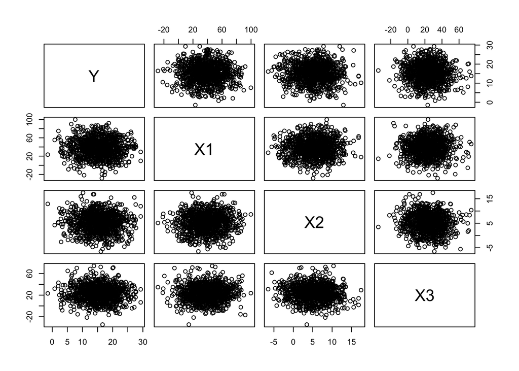

```r
plot(orig)
```

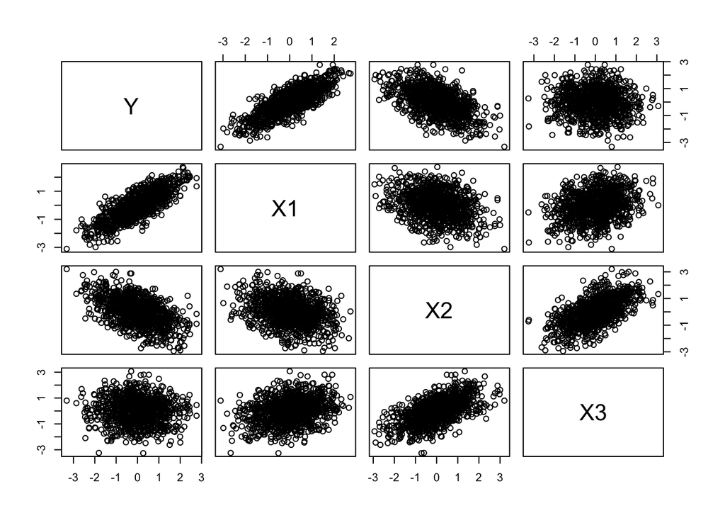

```r
plot(new)  # note the axis scales; using `pairs(new)` would plot the same
```

can see the effect of having correlated variables.

```r
df <- sweep(new, 2, STATS = sds, FUN = "*")  # scale back out to original mean...
df <- sweep(df, 2, STATS = ms, FUN = "+")  # and standard deviation
head(df)
```

```
##           Y       X1         X2         X3
## 1 19.461125 67.39636  9.0108864 48.9220862
## 2 14.014247 14.57122  0.8136102 -0.7238002
## 3 22.349526 66.48529  4.4349706 32.5920497
## 4  9.771728 41.46052  8.6673913 42.0705284
## 5 20.746587 48.47740  1.4196078 17.5547720
## 6 15.608773 26.61161 -1.4944507 -7.9136548
```

```r
cor(df)
```

```
##              Y         X1         X2          X3
## Y   1.00000000  0.7974951 -0.5257251 -0.05777159
## X1  0.79749514  1.0000000 -0.2995730  0.28226504
## X2 -0.52572505 -0.2995730  1.0000000  0.60710780
## X3 -0.05777159  0.2822650  0.6071078  1.00000000
```

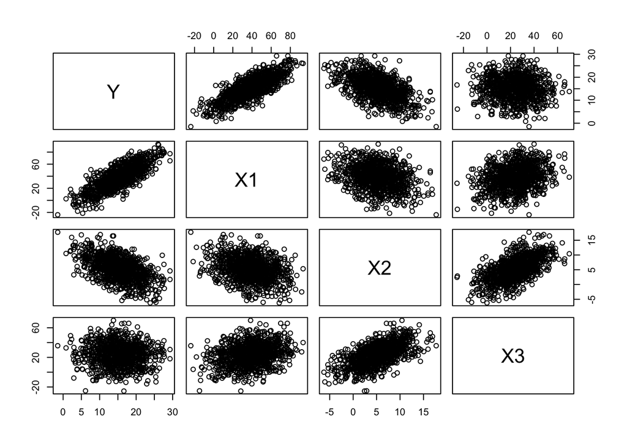

```r
plot(df)  # note the change to the axis scales; using `pairs(d)` would produce the same plot
```

CHALLENGE

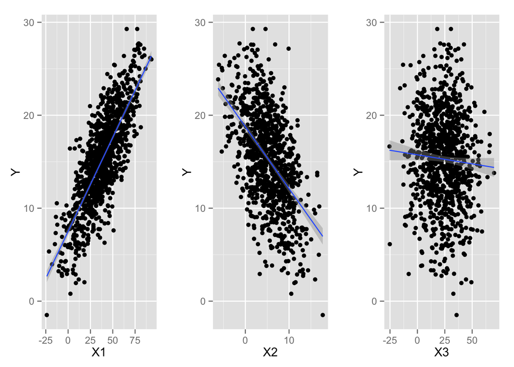

```r
library(ggplot2)
require(gridExtra) # par command for ggplot
g1 <- ggplot(data = df, aes(x = X1, y = Y)) + geom_point() + geom_smooth(method = "lm",
    formula = y ~ x)
g2 <- ggplot(data = df, aes(x = X2, y = Y)) + geom_point() + geom_smooth(method = "lm",
    formula = y ~ x)
g3 <- ggplot(data = df, aes(x = X3, y = Y)) + geom_point() + geom_smooth(method = "lm",
    formula = y ~ x)
grid.arrange(g1, g2, g3, ncol = 3)
```

0.8 positive correlation negative 0 correlation between y and x3

we defined all of these

```r
m1 <- lm(data = df, formula = Y ~ X1)
summary(m1)
```

```
##
## Call:
## lm(formula = Y ~ X1, data = df)
##
## Residuals:
##      Min       1Q   Median       3Q      Max
## -10.1847  -2.0417   0.0631   2.0110   8.5162
##
## Coefficients:
##             Estimate Std. Error t value Pr(>|t|)
## (Intercept) 7.500755   0.209942   35.73   <2e-16 ***
## X1          0.202217   0.004843   41.76   <2e-16 ***
## ---
## Signif. codes:  0 '***' 0.001 '**' 0.01 '*' 0.05 '.' 0.1 ' ' 1
##
## Residual standard error: 3.055 on 998 degrees of freedom
## Multiple R-squared:  0.636,  Adjusted R-squared:  0.6356
## F-statistic:  1744 on 1 and 998 DF,  p-value: < 2.2e-16
```

```r
m2 <- lm(data = df, formula = Y ~ X2)
summary(m2)
```

```
##
## Call:
## lm(formula = Y ~ X2, data = df)
##
## Residuals:
##      Min       1Q   Median       3Q      Max
## -13.6409  -2.7955  -0.0019   2.8457  14.9925
##
## Coefficients:
##             Estimate Std. Error t value Pr(>|t|)
## (Intercept) 18.75844    0.22407   83.72   <2e-16 ***
## X2          -0.66563    0.03409  -19.52   <2e-16 ***
## ---
## Signif. codes:  0 '***' 0.001 '**' 0.01 '*' 0.05 '.' 0.1 ' ' 1
##
## Residual standard error: 4.307 on 998 degrees of freedom
## Multiple R-squared:  0.2764, Adjusted R-squared:  0.2757
## F-statistic: 381.2 on 1 and 998 DF,  p-value: < 2.2e-16
```

```r
m3 <- lm(data = df, formula = Y ~ X3)
summary(m3)
```

```
##
## Call:
## lm(formula = Y ~ X3, data = df)
##
## Residuals:
##     Min      1Q  Median      3Q     Max
## -16.541  -3.399   0.173   3.425  14.128
##
## Coefficients:
##             Estimate Std. Error t value Pr(>|t|)
## (Intercept) 15.74558    0.29858  52.735   <2e-16 ***
## X3          -0.01944    0.01063  -1.828   0.0678 .
## ---
## Signif. codes:  0 '***' 0.001 '**' 0.01 '*' 0.05 '.' 0.1 ' ' 1
##
## Residual standard error: 5.054 on 998 degrees of freedom
## Multiple R-squared:  0.003338,   Adjusted R-squared:  0.002339
## F-statistic: 3.342 on 1 and 998 DF,  p-value: 0.06783
```

In simple linear regression, YY has a significant, positive relationship with X1X1, a signficant negative relationship with X2X2, and no significant bivariate relationship with X3X3.

looking at coefficients for m1 - positive and significant, etc etc.

Now let’s move on to doing actual multiple regression. To review, with multiple regression, we are looking to model a response variable in terms of two or more predictor variables so we can evaluate the effect of several explanatory variables.

Using lm() and formula notation, we can fit a model with all three predictor variables. The + sign is used to add additional predictors to our model.

```r
m <- lm(data = df, formula = Y ~ X1 + X2 + X3)
coef(m) ## gives you the beta values
```

```
## (Intercept)          X1          X2          X3
## 10.17230777  0.19955057 -0.24068964 -0.05534425
```

```r
summary(m) # whole model output ##x3 covaries with other significant variables e.g. 60% covaries with x2. so now x3 also has significance.
```

```
##
## Call:
## lm(formula = Y ~ X1 + X2 + X3, data = df)
##
## Residuals:
##    Min     1Q Median     3Q    Max
## -7.515 -1.745 -0.014  1.680  8.127
##
## Coefficients:
##              Estimate Std. Error t value Pr(>|t|)
## (Intercept) 10.172308   0.246932  41.195  < 2e-16 ***
## X1           0.199551   0.005461  36.538  < 2e-16 ***
## X2          -0.240690   0.032923  -7.311 5.45e-13 ***
## X3          -0.055344   0.008701  -6.361 3.05e-10 ***
## ---
## Signif. codes:  0 '***' 0.001 '**' 0.01 '*' 0.05 '.' 0.1 ' ' 1
##
## Residual standard error: 2.599 on 996 degrees of freedom
## Multiple R-squared:  0.7371, Adjusted R-squared:  0.7363
## F-statistic: 930.6 on 3 and 996 DF,  p-value: < 2.2e-16
```

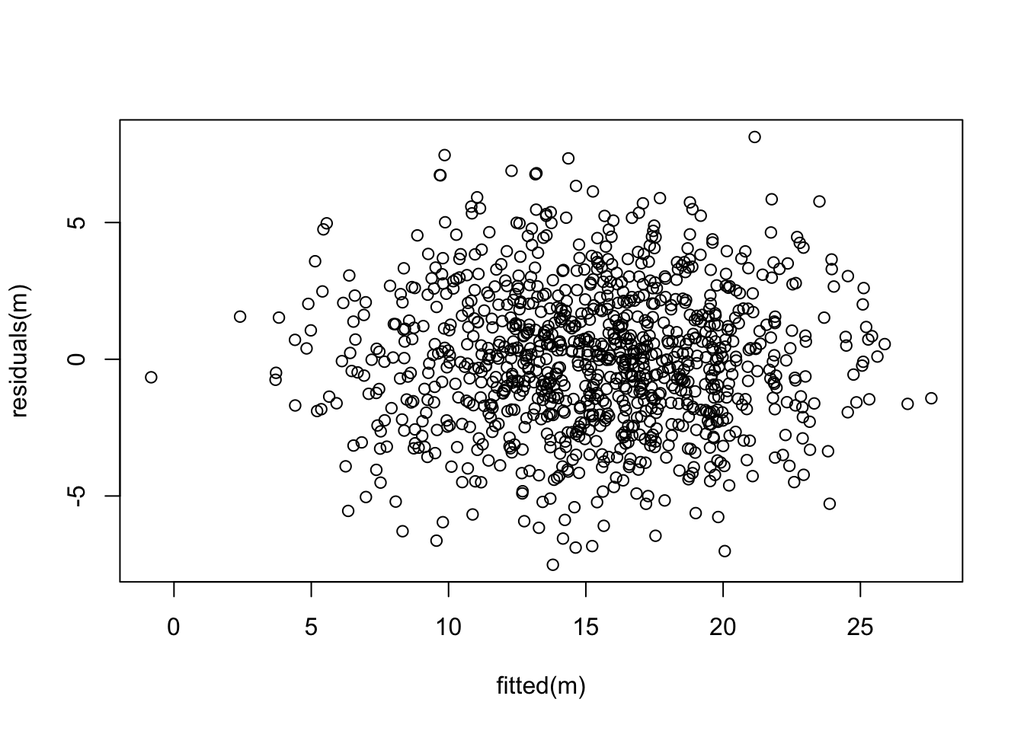

```r
# let's check if our residuals are random normal...
plot(fitted(m), residuals(m)) # random cloud is what we want
```

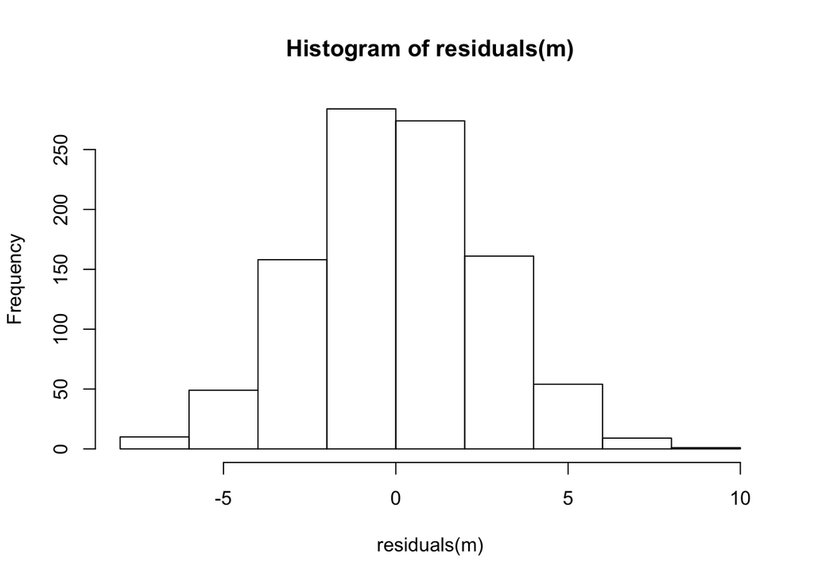

```r
#if structure (line, or a cloud with a slope ) here --> means there's some covariate that we haven't accounted for in our model , can't trust our results.
# bc only supposed to represent random error. all that our model isn't accounting for is random error.

hist(residuals(m))
```

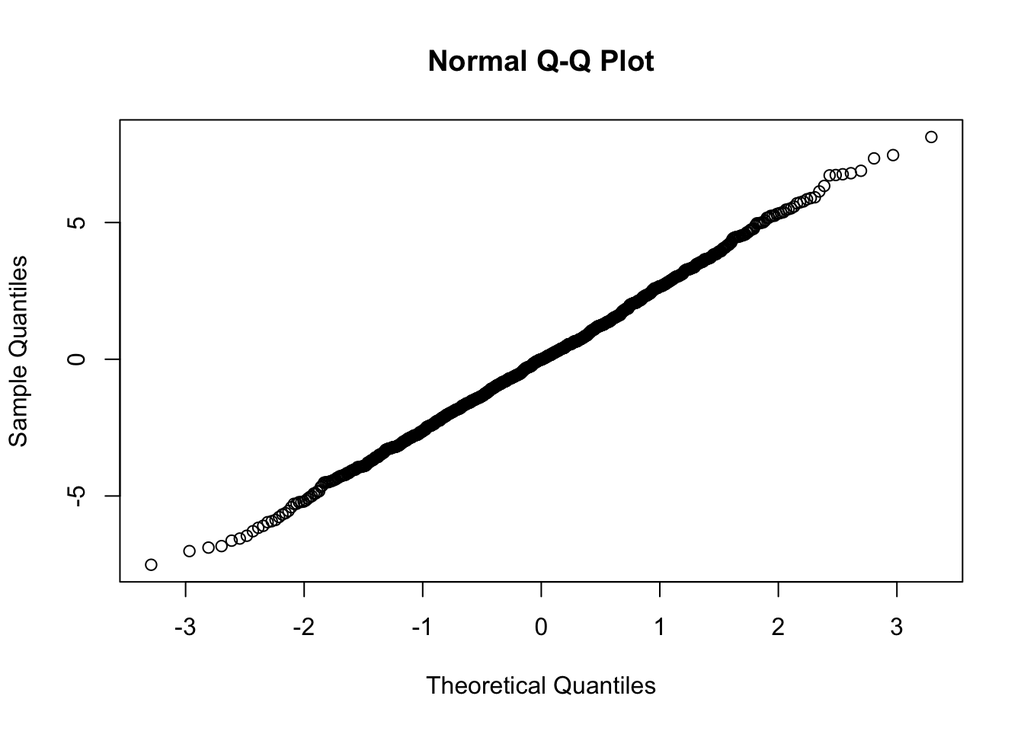

```r
qqnorm(residuals(m))
```

calculate the F statistic

```r
f <- (summary(m)$r.squared * (nrow(df) - (ncol(df) - 1) - 1))/((1 - summary(m)$r.squared) *
    (ncol(df) - 1))
f
```

```
## [1] 930.6204
```

Challenge

```r
library(curl)
f <- curl("https://raw.githubusercontent.com/fuzzyatelin/fuzzyatelin.github.io/master/AN597_Fall17/zombies.csv")
z <- read.csv(f, header = TRUE, sep = ",", stringsAsFactors = TRUE)
head(z)
```

```
##   id first_name last_name gender   height   weight zombies_killed
## 1  1      Sarah    Little Female 62.88951 132.0872              2
## 2  2       Mark    Duncan   Male 67.80277 146.3753              5
## 3  3    Brandon     Perez   Male 72.12908 152.9370              1
## 4  4      Roger   Coleman   Male 66.78484 129.7418              5
## 5  5      Tammy    Powell Female 64.71832 132.4265              4
## 6  6    Anthony     Green   Male 71.24326 152.5246              1
##   years_of_education                           major      age
## 1                  1                medicine/nursing 17.64275
## 2                  3 criminal justice administration 22.58951
## 3                  1                       education 21.91276
## 4                  6                  energy studies 18.19058
## 5                  3                       logistics 21.10399
## 6                  4                  energy studies 21.48355
```

```r
m <- lm(data = z, height ~ weight + age)
summary(m)
```

```
##
## Call:
## lm(formula = height ~ weight + age, data = z)
##
## Residuals:
##     Min      1Q  Median      3Q     Max
## -5.2278 -1.1782 -0.0574  1.1566  5.4117
##
## Coefficients:
##              Estimate Std. Error t value Pr(>|t|)
## (Intercept) 31.763388   0.470797   67.47   <2e-16 ***
## weight       0.163107   0.002976   54.80   <2e-16 ***
## age          0.618270   0.018471   33.47   <2e-16 ***
## ---
## Signif. codes:  0 '***' 0.001 '**' 0.01 '*' 0.05 '.' 0.1 ' ' 1
##
## Residual standard error: 1.64 on 997 degrees of freedom
## Multiple R-squared:  0.8555, Adjusted R-squared:  0.8553
## F-statistic:  2952 on 2 and 997 DF,  p-value: < 2.2e-16
```

```r
library(car)
m <- lm(data = z, formula = height ~ gender + age)
summary(m)
```

```
##
## Call:
## lm(formula = height ~ gender + age, data = z)
##
## Residuals:
##      Min       1Q   Median       3Q      Max
## -10.1909  -1.7173   0.1217   1.7670   7.6746
##
## Coefficients:
##             Estimate Std. Error t value Pr(>|t|)
## (Intercept) 46.74251    0.56869   82.19   <2e-16 ***
## genderMale   4.00224    0.16461   24.31   <2e-16 ***
## age          0.94091    0.02777   33.88   <2e-16 ***
## ---
## Signif. codes:  0 '***' 0.001 '**' 0.01 '*' 0.05 '.' 0.1 ' ' 1
##
## Residual standard error: 2.603 on 997 degrees of freedom
## Multiple R-squared:  0.6361, Adjusted R-squared:  0.6354
## F-statistic: 871.5 on 2 and 997 DF,  p-value: < 2.2e-16
```

```r
m.aov <- Anova(m, type = "II")
m.aov
```

```
## Anova Table (Type II tests)
##
## Response: height
##           Sum Sq  Df F value    Pr(>F)
## gender    4003.9   1  591.15 < 2.2e-16 ***
## age       7775.6   1 1148.01 < 2.2e-16 ***
## Residuals 6752.7 997
## ---
## Signif. codes:  0 '***' 0.001 '**' 0.01 '*' 0.05 '.' 0.1 ' ' 1
```

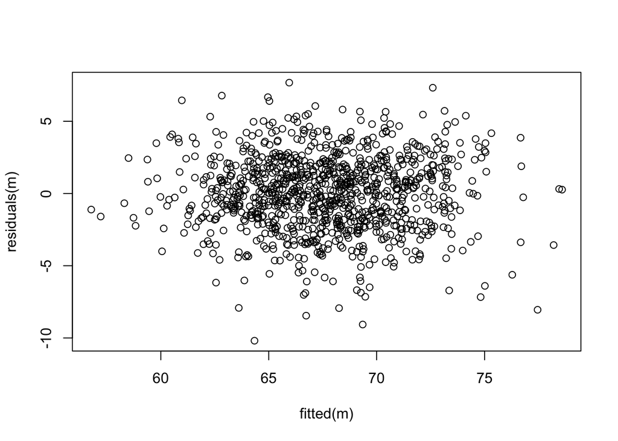

```r
plot(fitted(m), residuals(m))
```

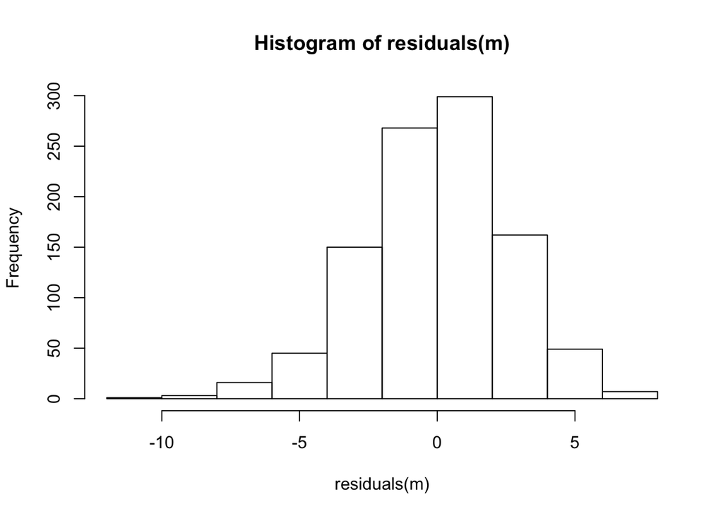

```r
hist(residuals(m))
```

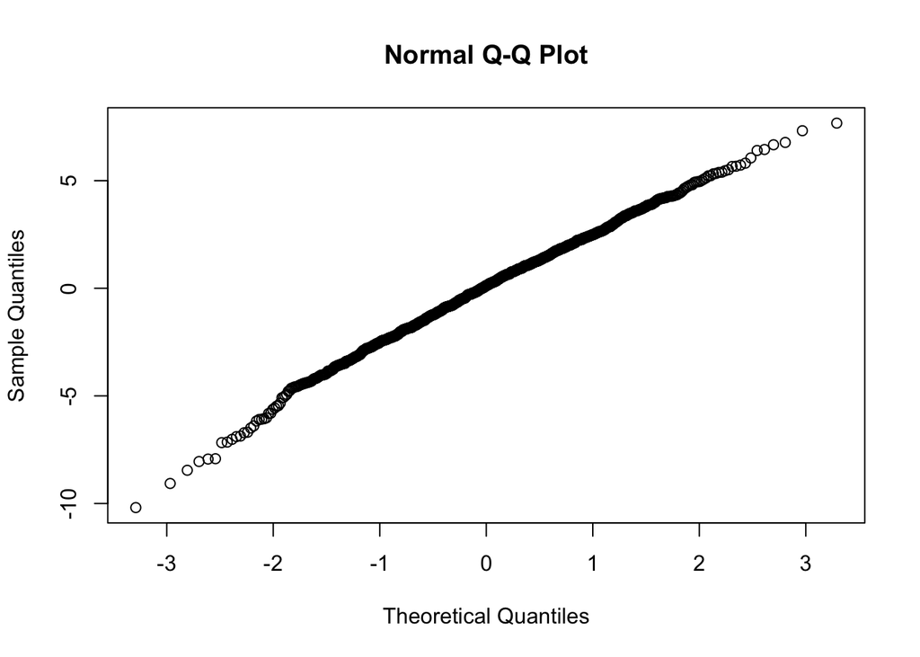

```r
qqnorm(residuals(m))
```

OUTPUT: “Controlling for age, being male adds 4 inches to predicted height when compared to being female.”

visualize the results separately for males and females

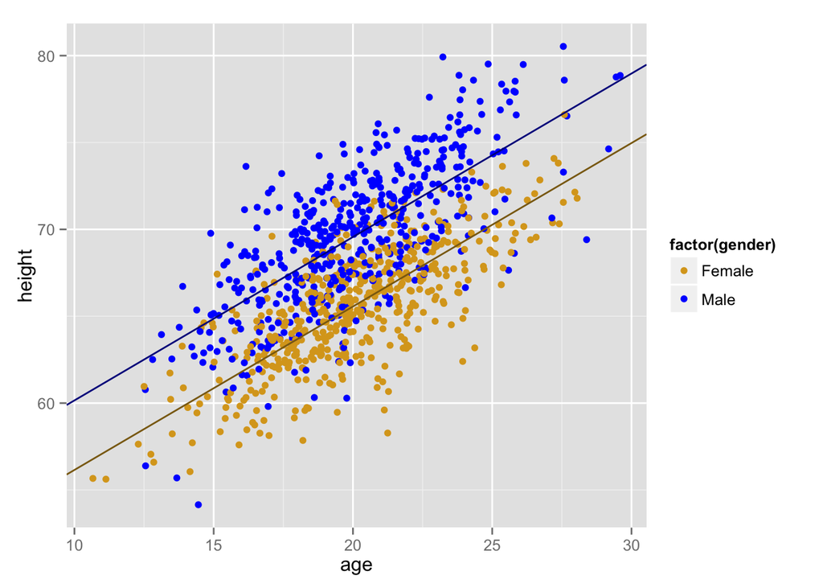

```r
library(ggplot2)
p <- ggplot(data = z, aes(x = age, y = height)) + geom_point(aes(color = factor(gender))) +
    scale_color_manual(values = c("goldenrod", "blue"))
p <- p + geom_abline(slope = m$coefficients[3], intercept = m$coefficients[1],
    color = "goldenrod4")
p <- p + geom_abline(slope = m$coefficients[3], intercept = m$coefficients[1] +
    m$coefficients[2], color = "darkblue")
p
```

getting CIs

```r
m <- lm(data = z, formula = height ~ age + gender)
summary(m)
```

```
##
## Call:
## lm(formula = height ~ age + gender, data = z)
##
## Residuals:
##      Min       1Q   Median       3Q      Max
## -10.1909  -1.7173   0.1217   1.7670   7.6746
##
## Coefficients:
##             Estimate Std. Error t value Pr(>|t|)
## (Intercept) 46.74251    0.56869   82.19   <2e-16 ***
## age          0.94091    0.02777   33.88   <2e-16 ***
## genderMale   4.00224    0.16461   24.31   <2e-16 ***
## ---
## Signif. codes:  0 '***' 0.001 '**' 0.01 '*' 0.05 '.' 0.1 ' ' 1
##
## Residual standard error: 2.603 on 997 degrees of freedom
## Multiple R-squared:  0.6361, Adjusted R-squared:  0.6354
## F-statistic: 871.5 on 2 and 997 DF,  p-value: < 2.2e-16
```

```r
confint(m, level = 0.95)
```

```
##                  2.5 %     97.5 %
## (Intercept) 45.6265330 47.8584809
## age          0.8864191  0.9954081
## genderMale   3.6792172  4.3252593
```

Similarly, using predict() allows us to determine confidence intervals for the predicted mean response and prediction intervals for individual responses for a given combination of predictor variables.

What is the estimated mean height, in inches, for a 29 year old male who has survived the zombie apocalypse?

```r
ci <- predict(m, newdata = data.frame(age = 29, gender = "Male"), interval = "confidence",
    level = 0.95)
ci
```

```
##        fit      lwr      upr
## 1 78.03124 77.49345 78.56903
```

```r
#newdata call = specific thing we'd like to predict
```

What is the 95% confidence interval around this mean height?

```r
ci <- predict(m, newdata = data.frame(age = 29, gender = "Male"), interval = "confidence",
    level = 0.95)
ci
```

```
##        fit      lwr      upr
## 1 78.03124 77.49345 78.56903
```

What is the 95% prediction interval for the individual heights of 29 year old male survivors?

```r
pi <- predict(m, newdata = data.frame(age = 29, gender = "Male"), interval = "prediction",
    level = 0.95)
pi
```

```
##        fit      lwr      upr
## 1 78.03124 72.89597 83.16651
```